# Sensitivity analysis

Supplementary Information

# The aim

- To test whether the modelling results were sensitive to the photoreceptor ratios used, we repeated these analyses using published ratios that represent the known variation in insects. Specifically, we compared the changes in contrast when shifting the LWS peak from 580 nm to 660 nm between tetrachomat visual systems with different photoreceptor ratios.
- We applied the same modelling method described in the Main models but using ratios of different insects, including the jewel beetle, *Agrilus planipennis* (same as the ratio used in the main text; 1.14: 1: 1.26: 1.38; UVS: SWS: MWS: LWS), and two butterflies, *Papilio Xuthus* (1: 1: 4.08: 2.92) and *Heliconius sp.* type III (1.00: 1.44: 2.22: 11.11).
- The model parameters and the statistical methods remain the same as described in main text of the paper.

```r
library(pavo)
library(dplyr)
library(stringr)
library(tidyr) #for gather() function
library(ggplot2)
library(lme4)
library(car)
library(multcomp)
library(boot) #for mean() function
library(pander) #for creating tidy tables
library(ggpubr) #for ggarrange() function
```

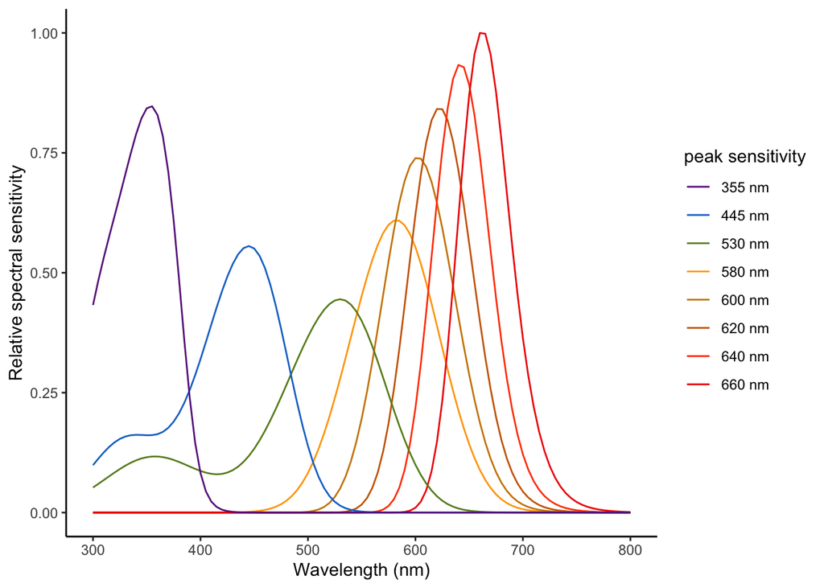

Figure caption: Sensitivity curves of the photoreceptors with different peak wavelengths.

```r
wl <- specsensbuprest.model2[,1]
peaks <- gather(specsensbuprest.model2[,2:9], peak, value) %>%
  cbind(wl)

#order the peaks in the legend
peak.order <- c("UVS.355.A1.", "SWS.445.A1.", "MWS.530.A1.", "LWS.570.A1..filter580.", "LWS.570.A1..filter600.", "LWS.570.A1..filter620.", "LWS.570.A1..filter640.", "LWS.570.A1..filter660.")

ggplot(peaks,
       aes(x = wl,
                 y = value,
                 col = peak))+
  geom_line()+
  guides(color = guide_legend(title = "peak sensitivity"))+
  scale_color_manual(
    values = c("darkorchid4", "dodgerblue3", "olivedrab4", "orange1", "orange3","darkorange3", "orangered1", "red2"),
    labels = c("355 nm", "445 nm","530 nm", "580 nm", "600 nm", "620 nm", "640 nm", "660 nm" ),
    breaks = peak.order)+
  xlab("Wavelength (nm)")+
  ylab("Relative spectral sensitivity")+
  theme_classic()
```

# Data description

We used the same spectral data and daylight illumination described in the Main models section.

# Run the visual models

- We created 3 different visual systems using different receptor ratios from 3 insect species (UVS, SWS, MWS, LWS):
- *Agrilus planipennis*: 1.14, 1, 1.26, 1.38
- *Papilio xuthus*: 1, 1, 4.08, 2.92
- *Heliconius* sp. type III : 1, 1.44, 2.22, 11.11
- We ran the visual models with the same parameter settings and steps as in the Main models.
- We first calculated the quantum catches, then calculated the contrasts.

```r
get.d65.vismodel <- function(i){

  vs.i <- vismodel(dataset[1:501,],
                   visual = i, #this need to change according to the visual system
                   bkg = aveleaf$aveleaf,
                   illum = irradiance.d65[1:501,2],
                   qcatch = 'fi',
                   relative = FALSE,
                   vonkries = TRUE)
  return(vs.i)
}
```

```r
#shared between 3 species
sens.list <- list(VS580 <- specsensbuprest.model2[, 1:5],
                  VS600 <- specsensbuprest.model2[, c(1,2,3,4,6)],
                  VS620 <- specsensbuprest.model2[, c(1,2,3,4,7)],
                  VS640 <- specsensbuprest.model2[, c(1,2,3,4,8)],
                  VS660 <- specsensbuprest.model2[, c(1,2,3,4,9)])
d65.vismodel.output <- list(VS580 = NA, VS600 = NA, VS620 = NA, VS640 = NA, VS660 = NA)

# Set a loop for calculating quantum catch for each visual system
for (i in 1:length(sens.list)){

  vs.result.d65 <- get.d65.vismodel(sens.list[[i]]) # for D65
  d65.vismodel.output[[i]] <- vs.result.d65
}

buprest580 <- d65.vismodel.output$VS580
buprest600 <- d65.vismodel.output$VS600
buprest620 <- d65.vismodel.output$VS620
buprest640 <- d65.vismodel.output$VS640
buprest660 <- d65.vismodel.output$VS660
```

```r
recep.density.list <- list(Agrilus <- c(1.14, 1, 1.26, 1.38),
                                Papilio <- c(1, 1, 4.08, 2.92),
                                Heliconius <- c(1, 1.44, 2.22, 11.11))

get.sens.coldist <- function(i, sp){

  con <- coldist(modeldata = i, # put output of vismodel()
                   noise = "neural",
                   achro = FALSE,
                   n = recep.density.list[[sp]],
                   weber = 0.12,
                   weber.ref = 4)

  return(con)
}

vismodel.list <- list(buprest580,
                      buprest600,
                      buprest620,
                      buprest640,
                      buprest660)
#for Agrilus planipennis
Agrilus.contrast.output <- list(VS580 = NA, VS600 = NA, VS620 = NA, VS640 = NA, VS660 = NA)

for (i in 1:length(vismodel.list)) {

  contrast.result.i <- get.sens.coldist(vismodel.list[[i]], 1)
  Agrilus.contrast.output[[i]] <- contrast.result.i
}

Cbuprest580 <- Agrilus.contrast.output$VS580
Cbuprest600 <- Agrilus.contrast.output$VS600
Cbuprest620 <- Agrilus.contrast.output$VS620
Cbuprest640 <- Agrilus.contrast.output$VS640
Cbuprest660 <- Agrilus.contrast.output$VS660


#for Papilio xuthus
Papilio.contrast.output <- list(VS580 = NA, VS600 = NA, VS620 = NA, VS640 = NA, VS660 = NA)

for (i in 1:length(vismodel.list)) {

  contrast.result.i <- get.sens.coldist(vismodel.list[[i]], 2)
  Papilio.contrast.output[[i]] <- contrast.result.i
}

Cpapilio580 <- Papilio.contrast.output$VS580
Cpapilio600 <- Papilio.contrast.output$VS600
Cpapilio620 <- Papilio.contrast.output$VS620
Cpapilio640 <- Papilio.contrast.output$VS640
Cpapilio660 <- Papilio.contrast.output$VS660

#for Heliconius sp
Heliconius.contrast.output <- list(VS580 = NA, VS600 = NA, VS620 = NA, VS640 = NA, VS660 = NA)

for (i in 1:length(vismodel.list)) {

  contrast.result.i <- get.sens.coldist(vismodel.list[[i]], 3)
  Heliconius.contrast.output[[i]] <- contrast.result.i
}

Cheliconius580 <- Heliconius.contrast.output$VS580
Cheliconius600 <- Heliconius.contrast.output$VS600
Cheliconius620 <- Heliconius.contrast.output$VS620
Cheliconius640 <- Heliconius.contrast.output$VS640
Cheliconius660 <- Heliconius.contrast.output$VS660
```

```r
#Organize data before GLMM
fl.vissys <- list("VS580.fl", "VS600.fl", "VS620.fl", "VS640.fl", "VS660.fl")
bl.vissys <- list("VS580.bl", "VS600.bl", "VS620.bl", "VS640.bl", "VS660.bl")
bf.vissys <- list("VS580.bf", "VS600.bf", "VS620.bf", "VS640.bf", "VS660.bf")


# for Agrilus planipennis
Agrilus.vissys <- list(Cbuprest580,
                       Cbuprest600,
                       Cbuprest620,
                       Cbuprest640,
                       Cbuprest660)
##flower vs leaf
allvis.fl.Agrilus <- data_frame()
for (i in 1:length(Agrilus.vissys)) {

  temp.i <- Agrilus.vissys[[i]] %>%
    filter(str_detect(patch1,"flower")) %>%
    filter(str_detect(patch2,"leaves")) %>%
    dplyr::select(1:3)

  temp.i$vissys <- strrep(fl.vissys[[i]],1)

  allvis.fl.Agrilus <- temp.i %>% rbind(allvis.fl.Agrilus)
}

### beetle vs leaf
allvis.bl.Agrilus <- data_frame()
for (i in 1:length(Agrilus.vissys)) {

  temp.i <- Agrilus.vissys[[i]] %>%
    filter(str_detect(patch1,"leaves")) %>%
    filter(str_detect(patch2,"beetle")) %>%
    dplyr::select(1:3)

  temp.i$vissys <- strrep(bl.vissys[[i]],1)

  allvis.bl.Agrilus <- temp.i %>% rbind(allvis.bl.Agrilus)
}

##beetle vs flower
allvis.bf.Agrilus <- data_frame()
for (i in 1:length(Agrilus.vissys)) {

  temp.i <- Agrilus.vissys[[i]] %>%
    filter(str_detect(patch1,"flower")) %>%
    filter(str_detect(patch2,"beetle")) %>%
    dplyr::select(1:3)

  temp.i$vissys <- strrep(bf.vissys[[i]],1)

  allvis.bf.Agrilus <- temp.i %>% rbind(allvis.bf.Agrilus)
}

#for Papilio xuthus
Papilio.vissys <- list(Cpapilio580,
                       Cpapilio600,
                       Cpapilio620,
                       Cpapilio640,
                       Cpapilio660)
##flower vs leaf
allvis.fl.Papilio <- data_frame()
for (i in 1:length(Papilio.vissys)) {

  temp.i <- Papilio.vissys[[i]] %>%
    filter(str_detect(patch1,"flower")) %>%
    filter(str_detect(patch2,"leaves")) %>%
    dplyr::select(1:3)

  temp.i$vissys <- strrep(fl.vissys[[i]],1)

  allvis.fl.Papilio <- temp.i %>% rbind(allvis.fl.Papilio)
}

##beetle vs leaf
allvis.bl.Papilio <- data_frame()
for (i in 1:length(Papilio.vissys)) {

  temp.i <- Papilio.vissys[[i]] %>%
    filter(str_detect(patch1,"leaves")) %>%
    filter(str_detect(patch2,"beetle")) %>%
    dplyr::select(1:3)

  temp.i$vissys <- strrep(bl.vissys[[i]],1)

  allvis.bl.Papilio <- temp.i %>% rbind(allvis.bl.Papilio)
}

##beetle vs flower
allvis.bf.Papilio <- data_frame()
for (i in 1:length(Papilio.vissys)) {

  temp.i <- Papilio.vissys[[i]] %>%
    filter(str_detect(patch1,"flower")) %>%
    filter(str_detect(patch2,"beetle")) %>%
    dplyr::select(1:3)

  temp.i$vissys <- strrep(bf.vissys[[i]],1)

  allvis.bf.Papilio <- temp.i %>% rbind(allvis.bf.Papilio)
}

#for Heliconius sp
Heliconius.vissys <- list(Cheliconius580,
                       Cheliconius600,
                       Cheliconius620,
                       Cheliconius640,
                       Cheliconius660)
##flower vs leaf
allvis.fl.Heliconius <- data_frame()
for (i in 1:length(Heliconius.vissys)) {

  temp.i <- Heliconius.vissys[[i]] %>%
    filter(str_detect(patch1,"flower")) %>%
    filter(str_detect(patch2,"leaves")) %>%
    dplyr::select(1:3)

  temp.i$vissys <- strrep(fl.vissys[[i]],1)

  allvis.fl.Heliconius <- temp.i %>% rbind(allvis.fl.Heliconius)
}

##beetle vs leaf
allvis.bl.Heliconius <- data_frame()
for (i in 1:length(Heliconius.vissys)) {

  temp.i <- Heliconius.vissys[[i]] %>%
    filter(str_detect(patch1,"leaves")) %>%
    filter(str_detect(patch2,"beetle")) %>%
    dplyr::select(1:3)

  temp.i$vissys <- strrep(bl.vissys[[i]],1)

  allvis.bl.Heliconius <- temp.i %>% rbind(allvis.bl.Heliconius)
}

##beetle vs flower
allvis.bf.Heliconius <- data_frame()
for (i in 1:length(Heliconius.vissys)) {

  temp.i <- Heliconius.vissys[[i]] %>%
    filter(str_detect(patch1,"flower")) %>%
    filter(str_detect(patch2,"beetle")) %>%
    dplyr::select(1:3)

  temp.i$vissys <- strrep(bf.vissys[[i]],1)

  allvis.bf.Heliconius <- temp.i %>% rbind(allvis.bf.Heliconius)
}
```

# Compare contrast

Click the tabs to see the results for each comparison group ( **Flower vs. Leaf** / **Beetle vs. Leaf** / **Beetle vs. Flower**) in 3 different speceis (*Agrilus planipennis* / *Papilio xuthus* / *Heliconius* sp).

```r
get.lmer.sens <- function(inputdat){

  lmer(dS ~ vissys + (1|patch2) + (1|patch1),
       data = inputdat, REML = F)
  #REML=F, in order to fit the model using the likelihood ratio test. Otherwise, the lmer default will fit the model using the REML (REstricted Maximum Likelihood) criterion.
}

get.posthocsum <- function(modelx){

  summary(glht(modelx,
               linfct = mcp(vissys = "Tukey")),
          test = adjusted("bonferroni"))
}
```

```r
# for Agrilus planipennis
## Flower vs Leaf
m.flower.vs.leaf.bup <- get.lmer.sens(allvis.fl.Agrilus)
sum.flower.vs.leaf.bup <- get.posthocsum(m.flower.vs.leaf.bup)

##Beetle vs Leaf
m.beetle.vs.leaf.bup <- get.lmer.sens(allvis.bl.Agrilus)
sum.beetle.vs.leaf.bup <- get.posthocsum(m.beetle.vs.leaf.bup)

##Beetle vs Flower
m.beetle.vs.flower.bup <- get.lmer.sens(allvis.bf.Agrilus)
sum.beetle.vs.flower.bup <- get.posthocsum(m.beetle.vs.flower.bup)

#for Papilio xuthus
##Flower vs Leaf
m.flower.vs.leaf.pap <- get.lmer.sens(allvis.fl.Papilio)
sum.flower.vs.leaf.pap <- get.posthocsum(m.flower.vs.leaf.pap)

##Beetle vs Leaf
m.beetle.vs.leaf.pap <- get.lmer.sens(allvis.bl.Papilio)
sum.beetle.vs.leaf.pap <- get.posthocsum(m.beetle.vs.leaf.pap)

##Beetle vs Flower
m.beetle.vs.flower.pap <- get.lmer.sens(allvis.bf.Papilio)
sum.beetle.vs.flower.pap <- get.posthocsum(m.beetle.vs.flower.pap)

#for Heliconius sp
##Flower vs Leaf
m.flower.vs.leaf.heli <- get.lmer.sens(allvis.fl.Heliconius)
sum.flower.vs.leaf.heli <- get.posthocsum(m.flower.vs.leaf.heli)

##Beetle vs Leaf
m.beetle.vs.leaf.heli <- get.lmer.sens(allvis.bl.Heliconius)
sum.beetle.vs.leaf.heli <- get.posthocsum(m.beetle.vs.leaf.heli)

##Beetle vs Flower
m.beetle.vs.flower.heli <- get.lmer.sens(allvis.bf.Heliconius)
sum.beetle.vs.flower.heli <- get.posthocsum(m.beetle.vs.flower.heli)
```

```r
vislist.heatmap <- list(
  c("VS 600", "VS 620","VS 640","VS 660","VS 620","VS 640","VS 660","VS 640","VS 660","VS 660"),
  c("VS 580","VS 580","VS 580","VS 580","VS 600","VS 600","VS 600","VS 620","VS 620","VS 640"))

# Set up the function
get.heatmap.datframe <- function(i,z){

  heatmapdat.i <- data.frame(as.numeric(str_extract(i[[1]],"([0-9]+).*$"))) %>%
    cbind(as.numeric(str_extract(i[[2]],"([0-9]+).*$"))) %>%
    cbind(as.numeric(str_extract(i[[3]],"([0-9]+).*$"))) %>%
    dplyr::rename(flower.vs.leaf = 1, beetle.vs.leaf = 2, beetle.vs.flower = 3) %>%
    cbind(z[[1]]) %>%
    cbind(z[[2]])

  colnames(heatmapdat.i)[4:5] <- c("VislistA", "VislistB")

  return(heatmapdat.i)
}
```

```r
# Create pvalue dataset
## for Agrilus planipennis
pdata.Agrilus <- list(sum.flower.vs.leaf.bup[["test"]][["pvalues"]],
                      sum.beetle.vs.leaf.bup[["test"]][["pvalues"]],
                      sum.beetle.vs.flower.bup[["test"]][["pvalues"]])

heat.Agrilus <- get.heatmap.datframe(pdata.Agrilus, vislist.heatmap)

## for Papilio xuthus
pdata.Papilio <- list(sum.flower.vs.leaf.pap[["test"]][["pvalues"]],
                      sum.beetle.vs.leaf.pap[["test"]][["pvalues"]],
                      sum.beetle.vs.flower.pap[["test"]][["pvalues"]])

heat.Papilio <- get.heatmap.datframe(pdata.Papilio, vislist.heatmap)

## for Heliconius sp
pdata.Heliconius <- list(sum.flower.vs.leaf.heli[["test"]][["pvalues"]],
                      sum.beetle.vs.leaf.heli[["test"]][["pvalues"]],
                      sum.beetle.vs.flower.heli[["test"]][["pvalues"]])

heat.Heliconius <- get.heatmap.datframe(pdata.Heliconius, vislist.heatmap)


# Assign asterisk signs
pdatalist <- list(heat.Agrilus, heat.Papilio, heat.Heliconius)

for (i in 1:length(pdatalist)) {

  pdatalist[[i]]$sig.flower.vs.leaf[pdatalist[[i]]$flower.vs.leaf > 0.05] <- ""
  pdatalist[[i]]$sig.flower.vs.leaf[pdatalist[[i]]$flower.vs.leaf < 0.05] <- "*"
  pdatalist[[i]]$sig.flower.vs.leaf[pdatalist[[i]]$flower.vs.leaf < 0.01] <- "**"
  pdatalist[[i]]$sig.flower.vs.leaf[pdatalist[[i]]$flower.vs.leaf < 0.0001] <- "***"
  pdatalist[[i]]$sig.beetle.vs.leaf[pdatalist[[i]]$beetle.vs.leaf > 0.05] <- ""
  pdatalist[[i]]$sig.beetle.vs.leaf[pdatalist[[i]]$beetle.vs.leaf < 0.05] <- "*"
  pdatalist[[i]]$sig.beetle.vs.leaf[pdatalist[[i]]$beetle.vs.leaf < 0.01] <- "**"
  pdatalist[[i]]$sig.beetle.vs.leaf[pdatalist[[i]]$beetle.vs.leaf < 0.0001] <- "***"
  pdatalist[[i]]$sig.beetle.vs.flower[pdatalist[[i]]$beetle.vs.flower > 0.05] <- ""
  pdatalist[[i]]$sig.beetle.vs.flower[pdatalist[[i]]$beetle.vs.flower < 0.05] <- "*"
  pdatalist[[i]]$sig.beetle.vs.flower[pdatalist[[i]]$beetle.vs.flower < 0.01] <- "**"
  pdatalist[[i]]$sig.beetle.vs.flower[pdatalist[[i]]$beetle.vs.flower < 0.0001] <- "***"

}

# Because we did the assignment on a data list, now we need to link the loop output back to the data respectively
heat.Agrilus <- pdatalist[[1]]
heat.Papilio <- pdatalist[[2]]
heat.Heliconius <- pdatalist[[3]]
```

```r
# a = data
# b = 1/2/3; 1 for flower.vs.leaf, 2 for beetle.vs.leaf, 3 for beetle.vs.flower
get.pheatmap <- function(a, b){ggplot(data = a,
                                        aes(x = VislistA,
                                            y = VislistB,
                                            fill = a[,b])) +
    geom_tile(colour = "white", size = 4)+
    geom_text(aes(VislistA,
                  VislistB,
                  label = paste(format(round(a[,b], 2), nsmall = 2),
                                a[, b+5])))+
    scale_fill_continuous(high = "#132B43", low = "#56B1F7", limit = c(0,1))+ #delete if want to reverse the colour
    theme_bw()+
    theme(axis.title.x = element_blank(),
          axis.title.y = element_blank(),
          panel.grid = element_blank(),
          panel.border = element_blank(),
          axis.ticks = element_blank() )+
    labs(fill = "p vaalue")

}
```